# fastml: Simplifying Machine Learning Workflows in R

Selcuk Korkmaz and Dincer Goksuluk

2024-12-02

## 1. Introduction

fastml is an R package designed to simplify and streamline the process of training machine learning models. It leverages the tidymodels ecosystem to provide a user-friendly interface for model training, evaluation, and prediction, allowing both beginners and experienced practitioners to build robust models with minimal code.

This vignette will guide you through the usage of the fastml package, starting from simple examples and progressively moving to more complex scenarios, including custom tuning of hyperparameters.

Comprehensive Dependency Packages List 1. Core Dependencies These packages are fundamental to the operation of the train_models function and the overall FastML package.

magrittr

Purpose: Provides the pipe operator (%>%) for chaining commands. Functions Used: %>% dplyr

Purpose: Data manipulation and transformation. Functions Used: filter, mutate, select, bind_rows, pull, bind_cols rlang

Purpose: Tools for programming with R, especially for handling non-standard evaluation. Functions Used: sym, syms dials

Purpose: Handles tuning parameters and their ranges. Functions Used: range_set, value_set, grid_regular, grid_latin_hypercube parsnip

Purpose: Defines and manages model specifications. Functions Used: fit, extract_parameter_set_dials workflows

Purpose: Manages modeling workflows, combining recipes and models. Functions Used: workflow, add_model, add_recipe tune

Purpose: Handles hyperparameter tuning. Functions Used: tune_grid, control_grid, select_best, finalize_workflow, finalize_model yardstick

Purpose: Provides tools for measuring model performance. Functions Used: metric_set, accuracy, kap, roc_auc, sens, spec, precision, f_meas, rmse, rsq, mae rsample

Purpose: Facilitates resampling methods for model evaluation. Functions Used: vfold_cv, bootstraps, validation_split recipes

Purpose: Manages data preprocessing steps. Functions Used: recipe, step_dummy, step_center, step_scale tibble

Purpose: Provides modern data frames. Functions Used: is_tibble ggplot2

Purpose: Data visualization. Functions Used: ggplot, aes, geom_bar, facet_wrap, theme_bw, theme, element_text, labs reshape2

Purpose: Data reshaping (melting and casting). Functions Used: melt, dcast stats

Purpose: Base R functions for statistical calculations. Functions Used: predict 2. Algorithm-Specific Dependencies These packages are required to train specific machine learning algorithms supported by FastML.

ranger

Purpose: Implements random forest models. Algorithms Supported: random_forest xgboost

Purpose: Provides gradient boosting models. Algorithms Supported: xgboost C50

Purpose: Implements the C5.0 decision tree algorithm. Algorithms Supported: c5.0 e1071

Purpose: Supports Support Vector Machines (SVM) and other algorithms. Algorithms Supported: svm_linear, svm_radial gbm

Purpose: Implements generalized boosted regression models. Algorithms Supported: gbm nnet

Purpose: Provides functions for neural networks. Algorithms Supported: neural_network kernlab

Purpose: Offers kernel-based machine learning methods. Algorithms Supported: Alternative for SVM (svm_radial) glmnet

Purpose: Implements elastic net regularization. Algorithms Supported: elastic_net rpart

Purpose: Implements recursive partitioning for decision trees. Algorithms Supported: decision_tree MASS

Purpose: Provides functions for linear and quadratic discriminant analysis. Algorithms Supported: lda, qda pls

Purpose: Implements Partial Least Squares regression. Algorithms Supported: pls lightgbm

Purpose: Gradient boosting framework by Microsoft. Algorithms Supported: lightgbm keras

Purpose: Interface to Keras for deep learning models. Algorithms Supported: deep_learning baguette

Purpose: Provides bagging methods for tree-based models. Algorithms Supported: bagging kknn

Purpose: Implements k-Nearest Neighbors. Algorithms Supported: kknn klaR

Purpose: Provides functions for classification and clustering. Algorithms Supported: klaR discrim

Purpose: Implements discriminant analysis. Algorithms Supported: discrim bonsai

Purpose: Implements pruning methods for tree-based models. Algorithms Supported: bonsai

## 2. Installation

Before using fastml, you need to install it and its dependencies. Since fastml relies on the tidymodels suite, make sure it’s installed as well.

```r
# Install tidymodels if not already installed
install.packages("tidymodels")
```

```r
# Install from CRAN
install.packages("fastml")

# If installing from GitHub
install.packages("devtools")
devtools::install_github("selcukorkmaz/fastml")
```

Load the necessary libraries:

```r
library(fastml)
library(tidymodels)
library(bonsai)
library(klaR)
library(discrim)
library(kknn)
library(rpart)
library(baguette)
library(mixOmics)
library(plsmod)

# reticulate::use_python("C:/Users/Selçuk/AppData/Local/Programs/Python/Python312/", required = TRUE)
# tensorflow::install_tensorflow()
```

## 3. Getting Started with fastml

### Simple Classification Example

We’ll begin by demonstrating how to use fastml for a simple classification task using the famous iris dataset.

```r
# Load the iris dataset
data(iris)
iris <- iris[iris$Species != "setosa", ]  # Binary classification
iris$Species <- factor(iris$Species)
```

```r
# View the first few rows
head(iris)
```

```
##    Sepal.Length Sepal.Width Petal.Length Petal.Width    Species
## 51          7.0         3.2          4.7         1.4 versicolor
## 52          6.4         3.2          4.5         1.5 versicolor
## 53          6.9         3.1          4.9         1.5 versicolor
## 54          5.5         2.3          4.0         1.3 versicolor
## 55          6.5         2.8          4.6         1.5 versicolor
## 56          5.7         2.8          4.5         1.3 versicolor
```

```r
# View classes of iris
table(iris$Species)
```

```
##
## versicolor  virginica
##         50         50
```

#### Training a Model with Default Settings

With fastml, you can train a model with minimal code:

```r
model <- fastml(
  data = iris,
  label = "Species"
)
```

By default, fastml will:

- Detect the task type (classification or regression) based on the target variable.
- Use default algorithms (16 classification algorithms) suitable for the task.
- Perform necessary preprocessing steps.
- Viewing the Model Summary
- You can get a summary of the trained models and their performance:

```r
# View the summary
summary(model)
```

```
##
## ===== fastml Model Summary =====
## Best Model: c5.0
##
## Performance Metrics for All Models:
##
##                          Model accuracy    f_meas kap precision roc_auc sens
##                           c5.0     0.95 0.9473684 0.9         1    1.00  0.9
##                            lda     0.95 0.9473684 0.9         1    0.99  0.9
##                    naive_bayes     0.95 0.9473684 0.9         1    1.00  0.9
##                            qda     0.95 0.9473684 0.9         1    0.99  0.9
##                  random_forest     0.95 0.9473684 0.9         1    0.98  0.9
##                         ranger     0.95 0.9473684 0.9         1    0.98  0.9
##                     svm_radial     0.95 0.9473684 0.9         1    1.00  0.9
##                        bagging     0.90 0.8888889 0.8         1    1.00  0.8
##                  decision_tree     0.90 0.8888889 0.8         1    0.92  0.8
##                            knn     0.90 0.8888889 0.8         1    0.95  0.8
##                       lightgbm     0.90 0.8888889 0.8         1    1.00  0.8
##            logistic_regression     0.90 0.8888889 0.8         1    0.90  0.8
##                 neural_network     0.90 0.8888889 0.8         1    0.98  0.8
##  penalized_logistic_regression     0.90 0.8888889 0.8         1    1.00  0.8
##                     svm_linear     0.90 0.8888889 0.8         1    1.00  0.8
##                        xgboost     0.90 0.8888889 0.8         1    0.99  0.8
##  spec
##     1
##     1
##     1
##     1
##     1
##     1
##     1
##     1
##     1
##     1
##     1
##     1
##     1
##     1
##     1
##     1
```

[output cut: 30 more lines]

```
## expr: ^NULL
## env:  empty
##
## $sample_size
## <quosure>
## expr: ^defaults$sample_size
## env:  0x0000020985f78ba0
##
## $stop_iter
## <quosure>
## expr: ^NULL
## env:  empty
##
##
## Generating performance comparison plots...
```

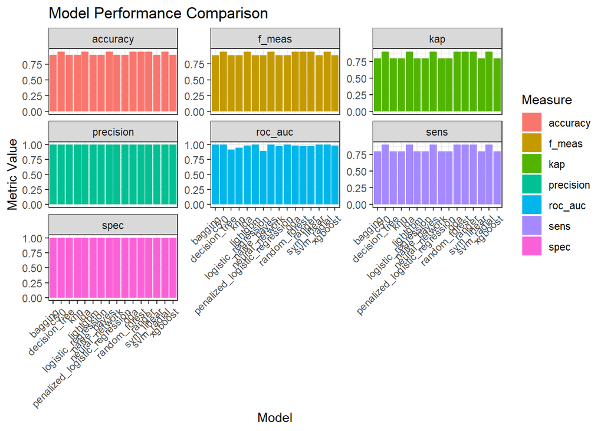

```
##
## To make predictions, use the 'predict' function.
## =================================
```

This will display:

- The best model selected based on performance.
- Performance metrics for all trained models.
- Hyperparameters of the best model.
- A comparison plot of model performances.

#### Making Predictions

To make predictions on new data:

```r
# Predict on new data (using a subset of the iris dataset as an example)
new_data <- iris[1:5, -5]  # Exclude the target variable
predictions <- predict(model, newdata = new_data)
predictions
```

```
## [1] versicolor versicolor versicolor versicolor versicolor
## Levels: versicolor virginica
```

### Simple Regression Example

Now, let’s see how fastml handles regression tasks using the mtcars dataset.

```r
# Load the mtcars dataset
data(mtcars)

# View the first few rows
head(mtcars)
```

```
##                    mpg cyl disp  hp drat    wt  qsec vs am gear carb
## Mazda RX4         21.0   6  160 110 3.90 2.620 16.46  0  1    4    4
## Mazda RX4 Wag     21.0   6  160 110 3.90 2.875 17.02  0  1    4    4
## Datsun 710        22.8   4  108  93 3.85 2.320 18.61  1  1    4    1
## Hornet 4 Drive    21.4   6  258 110 3.08 3.215 19.44  1  0    3    1
## Hornet Sportabout 18.7   8  360 175 3.15 3.440 17.02  0  0    3    2
## Valiant           18.1   6  225 105 2.76 3.460 20.22  1  0    3    1
```

Training a Regression Model

```r
# Train a regression model
model_reg <- fastml(
  data = mtcars,
  label = "mpg"
)
# View the summary
summary(model_reg)
```

```
##
## ===== fastml Model Summary =====
## Best Model: random_forest
##
## Performance Metrics for All Models:
##
##              Model      mae     rmse       rsq
##      random_forest 1.842111 2.017300 0.6944575
##                pls 1.897615 2.207832 0.7608983
##   ridge_regression 1.997483 2.302495 0.7378693
##                knn 1.968571 2.491001 0.5554691
##   lasso_regression 2.201155 2.502057 0.7381935
##        elastic_net 2.232999 2.520603 0.7351158
##     neural_network 2.151981 2.540331 0.6187416
##          bayes_glm 2.265675 2.544166 0.7307513
##  linear_regression 2.306087 2.589761 0.7266128
##            xgboost 2.480289 2.693820 0.5805182
##         svm_radial 2.617306 2.791949 0.4655665
##         svm_linear 2.494196 2.942404 0.6863406
##           lightgbm 2.810508 3.045781 0.5082444
##      decision_tree 2.701224 3.175879 0.4604420
##
## Best Model Hyperparameters:
##
## $mtry
## <quosure>
## expr: ^defaults$mtry
## env:  0x000002097d7a0b00
##
## $trees
## <quosure>
## expr: ^defaults$trees
## env:  0x000002097d7a0b00
##
## $min_n
## <quosure>
## expr: ^defaults$min_n
## env:  0x000002097d7a0b00
##
##
## Generating performance comparison plots...
```

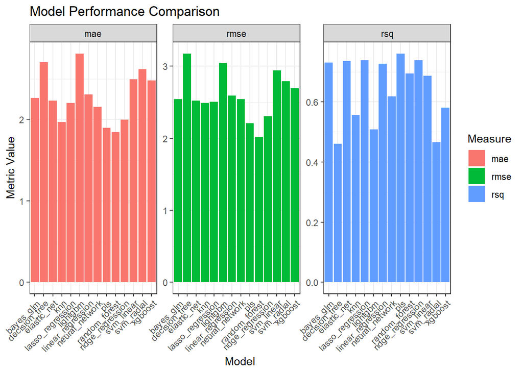

```
##
## To make predictions, use the 'predict' function.
## =================================
```

Making Predictions

```r
# Predict on new data
new_data_reg <- mtcars[1:5, -1]  # Exclude the target variable
predictions_reg <- predict(model_reg, newdata = new_data_reg)
predictions_reg
```

```
## [1] 20.34332 20.37115 24.30902 20.65228 16.78604
```

### Customizing fastml

####Specifying Algorithms

You can specify which algorithms to use by providing a vector of algorithm names:

```r
# Train models with specific algorithms
model_custom_algos <- fastml(
  data = iris,
  label = "Species",
  algorithms = c("random_forest", "xgboost", "svm_linear")
)
# View the summary
summary(model_custom_algos)
```

```
##
## ===== fastml Model Summary =====
## Best Model: random_forest
##
## Performance Metrics for All Models:
##
##          Model accuracy    f_meas kap precision roc_auc sens spec
##  random_forest     0.95 0.9473684 0.9         1    0.98  0.9    1
##     svm_linear     0.90 0.8888889 0.8         1    1.00  0.8    1
##        xgboost     0.90 0.8888889 0.8         1    0.99  0.8    1
##
## Best Model Hyperparameters:
##
## $mtry
## <quosure>
## expr: ^defaults$mtry
## env:  0x000002098cf52078
##
## $trees
## <quosure>
## expr: ^defaults$trees
## env:  0x000002098cf52078
##
## $min_n
## <quosure>
## expr: ^defaults$min_n
## env:  0x000002098cf52078
##
##
## Generating performance comparison plots...
```

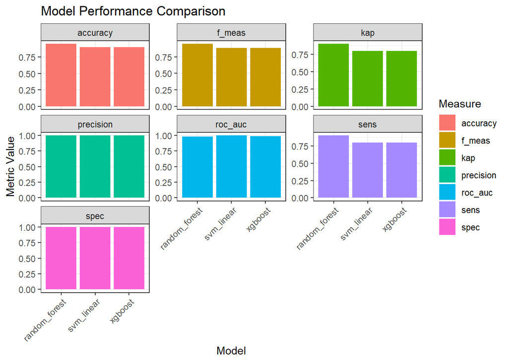

```
##
## To make predictions, use the 'predict' function.
## =================================
```

#### Setting Custom Resampling Methods

You can specify different resampling methods for cross-validation:

```r
# Train models with repeated cross-validation
model_repeated_cv <- fastml(
  data = iris,
  label = "Species",
  resampling_method = "repeatedcv",
  folds = 5,
  repeats = 3
)
# View the summary
summary(model_repeated_cv)
```

```
##
## ===== fastml Model Summary =====
## Best Model: c5.0
##
## Performance Metrics for All Models:
##
##                          Model accuracy    f_meas kap precision roc_auc sens
##                           c5.0     0.95 0.9473684 0.9         1    1.00  0.9
##                            lda     0.95 0.9473684 0.9         1    0.99  0.9
##                    naive_bayes     0.95 0.9473684 0.9         1    1.00  0.9
##                            qda     0.95 0.9473684 0.9         1    0.99  0.9
##                  random_forest     0.95 0.9473684 0.9         1    0.98  0.9
##                         ranger     0.95 0.9473684 0.9         1    0.98  0.9
##                     svm_radial     0.95 0.9473684 0.9         1    1.00  0.9
##                        bagging     0.90 0.8888889 0.8         1    1.00  0.8
##                  decision_tree     0.90 0.8888889 0.8         1    0.92  0.8
##                            knn     0.90 0.8888889 0.8         1    0.95  0.8
##                       lightgbm     0.90 0.8888889 0.8         1    1.00  0.8
##            logistic_regression     0.90 0.8888889 0.8         1    0.90  0.8
##                 neural_network     0.90 0.8888889 0.8         1    0.98  0.8
##  penalized_logistic_regression     0.90 0.8888889 0.8         1    1.00  0.8
##                     svm_linear     0.90 0.8888889 0.8         1    1.00  0.8
##                        xgboost     0.90 0.8888889 0.8         1    0.99  0.8
##  spec
##     1
##     1
##     1
##     1
##     1
##     1
##     1
##     1
##     1
##     1
##     1
##     1
##     1
##     1
##     1
##     1
```

[output cut: 30 more lines]

```
## expr: ^NULL
## env:  empty
##
## $sample_size
## <quosure>
## expr: ^defaults$sample_size
## env:  0x000002098c6b0880
##
## $stop_iter
## <quosure>
## expr: ^NULL
## env:  empty
##
##
## Generating performance comparison plots...
```

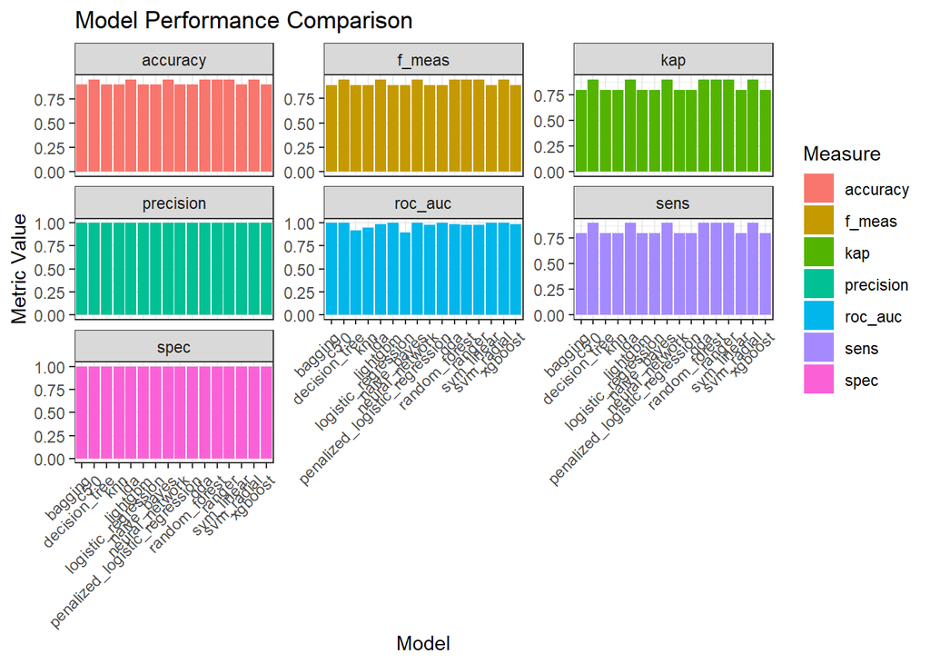

```
##
## To make predictions, use the 'predict' function.
## =================================
```

### Advanced Usage

#### Custom Hyperparameter Tuning

fastml allows you to define custom hyperparameter tuning grids for each algorithm.

##### Defining Custom Tuning Parameters

```r
# Define custom tuning parameters for random forest
tune_params_rf <- list(
  random_forest = list(
    mtry = c(1, 4),
    trees = c(50, 200),
    min_n = c(2, 10)
  )
)
```

```r
# Train the model with custom tuning parameters
model_custom_tune <- fastml(
  data = iris,
  label = "Species",
  algorithms = "random_forest",
  tune_params = tune_params_rf,
  use_default_tuning = TRUE  # Use default tuning grids for other algorithms if needed
)
```

```r
# View the summary
summary(model_custom_tune)
```

```
##
## ===== fastml Model Summary =====
## Best Model: random_forest
##
## Performance Metrics for All Models:
##
##          Model accuracy    f_meas kap precision roc_auc sens spec
##  random_forest      0.9 0.8888889 0.8         1    0.99  0.8    1
##
## Best Model Hyperparameters:
##
## $mtry
## <quosure>
## expr: ^2L
## env:  empty
##
## $trees
## <quosure>
## expr: ^50L
## env:  empty
##
## $min_n
## <quosure>
## expr: ^2L
## env:  empty
##
##
## Generating performance comparison plots...
```

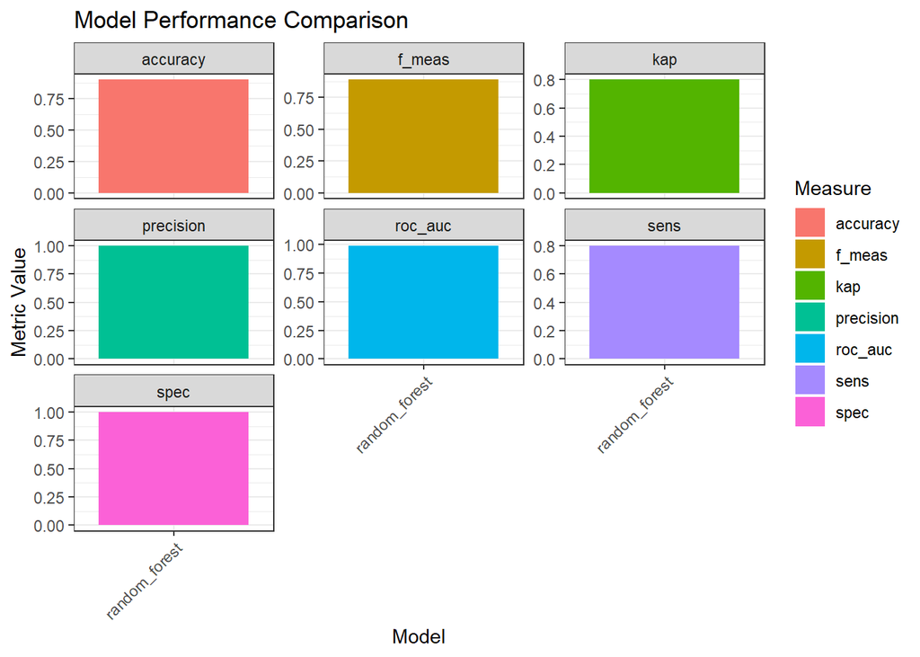

```
##
## To make predictions, use the 'predict' function.
## =================================
```